# Case study - gapminder

2019-11-04

## Slides online

### [Rmd on gitlab](https://git)

[https://tinyurl.com/gap-canbio](https://ginolhac.github.io/canbio/case_gapminder.html)

## Learning objectives

### You will learn to:

- use `dplyr` / `purrr` for efficient data manipulation
- tidying multiple linear models using `broom`
- managing related things together in **one** `tibble`
- summarise findings in one `ggplot` using relevant aesthetics

### guided practical

interactive session

## Managing multiple models

Tutorial based on the great conference by [Hadley Wickham](https://www.youtube.com/watch?v=rz3_FDVt9eg)

[figure not shown]

## list-column cheatsheet

### reminder

### `nest()`

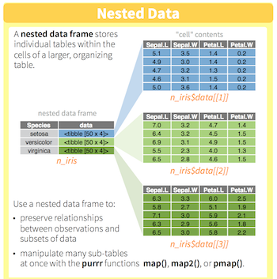

see [pdf on rstudio’ github repository](https://github.com/rstudio/cheatsheets/blob/master/source/pdfs/list-columns-cheatsheet.pdf)

## Keep all analyse steps (cols) per group (rows) together

### reminder

### workflow from last time

```r
mtcars %>%
  group_nest(cyl) %>%
  mutate(model = map(data, ~lm(mpg ~ wt, data = .x)),
         summary = map(model, summary),
         r_squared = map_dbl(summary, "r.squared"))
```

```
# A tibble: 3 x 5
    cyl data               model  summary    r_squared
  <dbl> <list>             <list> <list>         <dbl>
1     4 <tibble [11 × 10]> <lm>   <smmry.lm>     0.509
2     6 <tibble [7 × 10]>  <lm>   <smmry.lm>     0.465
3     8 <tibble [14 × 10]> <lm>   <smmry.lm>     0.423
```

## Gapminder

### [gapminder](http://www.gapminder.org/) is a fact tank

### dataset

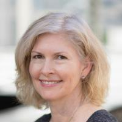

- from an independent Swedish foundation
- [R package](https://github.com/jennybc/gapminder) by [Jenny Bryan!](https://github.com/jennybc)
- install from CRAN: `gapminder`

### Hans Rosling

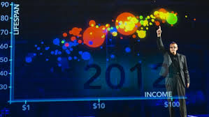

- died 2 years ago
- fundamentaly optimistic
- great [talk](https://www.ted.com/talks/hans_rosling_shows_the_best_stats_you_ve_ever_seen)

## Guided practical

### explore gapminder

`05:00`

- install the `gapminder` package
- load `gapminder` and `tidyverse` packages
- use the pipe `%>%` to pass `gapminder` to `ggplot()`
- **plot** the `life expectency` (`lifeExp` in `y`) ~ `year` (`x`)
- use `geom_line()`

### warning!

- mind the grouping!

## Gapminder

### global vs individual trend

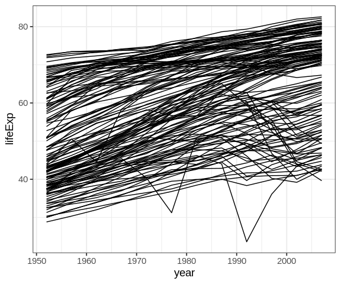

```r
library(gapminder)
gapminder %>%
  ggplot(aes(x = year, y = lifeExp, group = country)) +
  geom_line()
```

## Keep related things together using list-column

`04:00`

- add a column using `mutate()` named `year1950` which is:  
  `year` - 1950
- nest with `group_nest()` the tibble by `country` and `continent`
- how many rows will you get?  
  expectations help catching mistakes
- save the object as `by_country`

## Keep related things together

### `group_nest()`

### nest *per* country

```r
by_country <- gapminder %>%
  mutate(year1950 = year - 1950) %>%
  group_nest(continent, country)
by_country
```

```
# A tibble: 142 x 3
   continent country                  data
   <fct>     <fct>                    <list>
 1 Africa    Algeria                  <tibble [12 × 5]>
 2 Africa    Angola                   <tibble [12 × 5]>
 3 Africa    Benin                    <tibble [12 × 5]>
 4 Africa    Botswana                 <tibble [12 × 5]>
 5 Africa    Burkina Faso             <tibble [12 × 5]>
 6 Africa    Burundi                  <tibble [12 × 5]>
 7 Africa    Cameroon                 <tibble [12 × 5]>
 8 Africa    Central African Republic <tibble [12 × 5]>
 9 Africa    Chad                     <tibble [12 × 5]>
10 Africa    Comoros                  <tibble [12 × 5]>
# … with 132 more rows
```

### helpers

- be default the list column is named `data`
- `year1950` will help to get meaningful intercepts
- add `continent` to keep it along with `country`

## One country example

### Germany

### from original tibble

```r
gapminder %>%
  filter(country == "Germany") %>%
  select(-country, -continent)
```

```
# A tibble: 12 x 4
    year lifeExp      pop gdpPercap
   <int>   <dbl>    <int>     <dbl>
 1  1952    67.5 69145952     7144.
 2  1957    69.1 71019069    10188.
 3  1962    70.3 73739117    12902.
 4  1967    70.8 76368453    14746.
 5  1972    71   78717088    18016.
 6  1977    72.5 78160773    20513.
 7  1982    73.8 78335266    22032.
 8  1987    74.8 77718298    24639.
 9  1992    76.1 80597764    26505.
10  1997    77.3 82011073    27789.
11  2002    78.7 82350671    30036.
12  2007    79.4 82400996    32170.
```

### nested tibble

```r
by_country %>%
  filter(country == "Germany")
```

```
# A tibble: 1 x 3
  continent country data
  <fct>     <fct>   <list>
1 Europe    Germany <tibble [12 × 5]>
```

```r
by_country %>%
  filter(country == "Germany") %>%
  unnest(data)
```

```
# A tibble: 12 x 7
   continent country  year lifeExp      pop gdpPercap year1950
   <fct>     <fct>   <int>   <dbl>    <int>     <dbl>    <dbl>
 1 Europe    Germany  1952    67.5 69145952     7144.        2
 2 Europe    Germany  1957    69.1 71019069    10188.        7
 3 Europe    Germany  1962    70.3 73739117    12902.       12
 4 Europe    Germany  1967    70.8 76368453    14746.       17
 5 Europe    Germany  1972    71   78717088    18016.       22
 6 Europe    Germany  1977    72.5 78160773    20513.       27
 7 Europe    Germany  1982    73.8 78335266    22032.       32
 8 Europe    Germany  1987    74.8 77718298    24639.       37
 9 Europe    Germany  1992    76.1 80597764    26505.       42
10 Europe    Germany  1997    77.3 82011073    27789.       47
11 Europe    Germany  2002    78.7 82350671    30036.       52
12 Europe    Germany  2007    79.4 82400996    32170.       57
```

## What happens in the DATA FRAME, stays in the data frame

[video not shown]

## Las Vegas principle, add linear models

`06:00`

- using `by_country`
- add a new column `model` with linear regressions of `lifeExp` on `year1950`
- save as `by_country_lm`

### ask yourself

- if you see **add column**, do you use `mutate` or `summarise`?
- dealing with a list-column (here the column `data`), do you need to use `map`?

## Keep related things together

### linear models

### Linear model *per* country

```r
by_country_lm <- by_country %>%
  mutate(model = map(data, ~ lm(lifeExp ~ year1950, data = .x)))
by_country_lm
```

```
# A tibble: 142 x 4
   continent country                  data              model
   <fct>     <fct>                    <list>            <list>
 1 Africa    Algeria                  <tibble [12 × 5]> <lm>
 2 Africa    Angola                   <tibble [12 × 5]> <lm>
 3 Africa    Benin                    <tibble [12 × 5]> <lm>
 4 Africa    Botswana                 <tibble [12 × 5]> <lm>
 5 Africa    Burkina Faso             <tibble [12 × 5]> <lm>
 6 Africa    Burundi                  <tibble [12 × 5]> <lm>
 7 Africa    Cameroon                 <tibble [12 × 5]> <lm>
 8 Africa    Central African Republic <tibble [12 × 5]> <lm>
 9 Africa    Chad                     <tibble [12 × 5]> <lm>
10 Africa    Comoros                  <tibble [12 × 5]> <lm>
# … with 132 more rows
```

## Explore a list column

`03:00`

- count # rows per country using the `data` column
- does any country have less data than others?
- plot `lifeExp` ~ `year1950` for **Bulgaria** by unnesting `data`

### reminder

- a **list column** is a list, you need to iterate through elements
- for the plotting the steps are:
  - `filter()` for the desired country
  - `unnest()` raw `data`
  - pipe to `ggplot()`

## Explore a list column

### count how many rows per country

```r
by_country_lm %>%
  mutate(n = map_int(data, nrow)) %>%
  select(country, n)
```

```
# A tibble: 142 x 2
   country                      n
   <fct>                    <int>
 1 Algeria                     12
 2 Angola                      12
 3 Benin                       12
 4 Botswana                    12
 5 Burkina Faso                12
 6 Burundi                     12
 7 Cameroon                    12
 8 Central African Republic    12
 9 Chad                        12
10 Comoros                     12
# … with 132 more rows
```

```r
by_country_lm %>%
  mutate(n = map_int(data, nrow)) %>%
  distinct(n)
```

```
# A tibble: 1 x 1
      n
  <int>
1    12
```

### Bulgaria

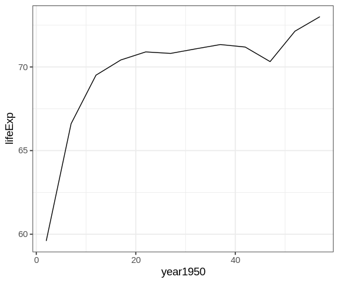

```r
by_country_lm %>%
  filter(country == "Bulgaria") %>%
  unnest(data) %>%
  ggplot(aes(x = year1950, y = lifeExp)) +
  geom_line()
```

## Explore nested tibble

`06:00`

- display the `summary` for the linear model of **Rwanda**
- how do you interpret the \(r^2\) for this particular model?

### reminder

- `filter()` for the desired country
- **list column** is a list
- to extract the `x`th element, use the `pluck("model", x)` `purrr` syntax
- pipe this unique model to `summary()`

## Explore nested tibble

### linear model for Rwanda

```r
by_country_lm %>%
  filter(country == "Rwanda") %>%
  pluck("model", 1) %>%
  summary()
```

```
Call:
lm(formula = lifeExp ~ year1950, data = .x)

Residuals:
    Min      1Q  Median      3Q     Max
-17.310  -1.445   2.410   3.073   6.021

Coefficients:
            Estimate Std. Error t value Pr(>|t|)
(Intercept) 42.83361    3.74890  11.426 4.63e-07 ***
year1950    -0.04583    0.10969  -0.418    0.685
---
Signif. codes:  0 '***' 0.001 '**' 0.01 '*' 0.05 '.' 0.1 ' ' 1

Residual standard error: 6.558 on 10 degrees of freedom
Multiple R-squared:  0.01716,   Adjusted R-squared:  -0.08112
F-statistic: 0.1746 on 1 and 10 DF,  p-value: 0.6849
```

\(r^2\) is close to 0, linearity sounds broken

`broom` will cleanup lm elements into tibbles

## broom cleanup

[figure not shown]

## Tidying models

### extract from nested lists

`06:00`

- using `by_country_lm`, add 4 new columns:
  - `glance`, using the broom function on the `model` column
  - `tidy`, using the broom function on the `model` column
  - `augment`, using the broom function on the `model` column
  - `rsq` from the `glance` column
- save as `models`
- why extracting the \(r^2\) in the main tibble is useful?

### reminder

- use `map` when dealing with a list column
- in `map`, shortcut with quotes (like `"r.squared"`) extract the specified variable
- `map` takes and returns a **list**. Use `map_dbl()` to coerce output to **doubles**

## Tidying models

### extract from nested lists

### useful info

- coefficients estimates:
  - **slope**
  - **intercept**
- \(r^2\)
- residuals

```r
library(broom)
models <- by_country_lm %>%
  mutate(glance  = map(model, glance),
         tidy    = map(model, tidy),
         augment = map(model, augment),
         rsq     = map_dbl(glance, "r.squared"))
models
```

```
# A tibble: 142 x 8
   continent country      data     model  glance   tidy    augment      rsq
   <fct>     <fct>        <list>   <list> <list>   <list>  <list>     <dbl>
 1 Africa    Algeria      <tibble… <lm>   <tibble… <tibbl… <tibble … 0.985
 2 Africa    Angola       <tibble… <lm>   <tibble… <tibbl… <tibble … 0.888
 3 Africa    Benin        <tibble… <lm>   <tibble… <tibbl… <tibble … 0.967
 4 Africa    Botswana     <tibble… <lm>   <tibble… <tibbl… <tibble … 0.0340
 5 Africa    Burkina Faso <tibble… <lm>   <tibble… <tibbl… <tibble … 0.919
 6 Africa    Burundi      <tibble… <lm>   <tibble… <tibbl… <tibble … 0.766
 7 Africa    Cameroon     <tibble… <lm>   <tibble… <tibbl… <tibble … 0.680
 8 Africa    Central Afr… <tibble… <lm>   <tibble… <tibbl… <tibble … 0.493
 9 Africa    Chad         <tibble… <lm>   <tibble… <tibbl… <tibble … 0.872
10 Africa    Comoros      <tibble… <lm>   <tibble… <tibbl… <tibble … 0.997
# … with 132 more rows
```

### extracting \(r^2\) in main tibble

- no need to unnest for sort / filtering.

## Exploratory plots

## plotting \(r^2\) for countries

`05:00`

- plot `country` ~ `rsq`
- **reorder** country levels by \(r^2\) (`rsq`): *snake plot*
- color points per continent
- which continent shows most of the low \(r^2\) values?

### reminder

to reorder discrete values:

- must be of data type `factor`
- use the `forcats` package
- `fct_reorder()` to reorder according to a continuous variable

## Do linear models fit all countries?

### snake plot

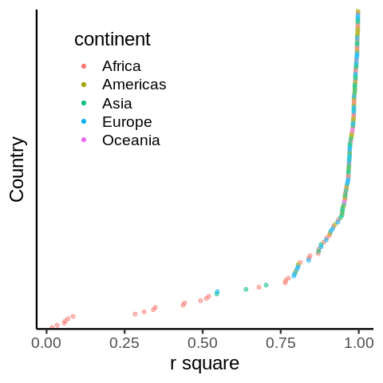

```r
library(forcats)
models %>%
  ggplot(aes(x = rsq,
             y = fct_reorder(country,
                             rsq))) +
  geom_point(aes(colour = continent),
             alpha = 0.5) +
  theme_classic(18) +
  theme(axis.text.y = element_blank(),
        axis.ticks.y = element_blank(),
        legend.position = c(0.25, 0.75)) +
   guides(color = guide_legend(
     override.aes = list(alpha = 1))) +
  labs(x = "r square",
       y = "Country")
```

## display the real data for countries with a low \(r^2\)

`04:00`

- focus on non-linear trends
- filter the 20 countries with the lowest \(r^2\)
- `unnest` column `data`
- plot `lifeExp` ~ `year` with lines
- colour per continent
- facet per country
- same questions for the **top 20** \(r^2\)

### reminder

- `arrange(col)` will sort according to `col`
- `top_n(x, col)` not only sort `col` but return only `x` top entries
- `top_n(x, desc(col))` same but sort from lowest values

## Exploratory plots

### focus on non-linear trends

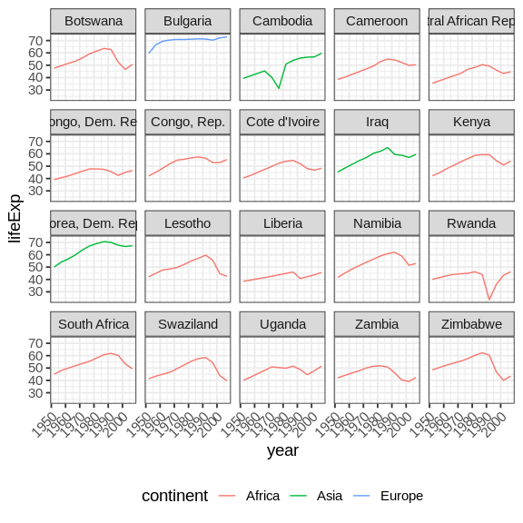

```r
models %>%
  top_n(20, desc(rsq)) %>%
  unnest(data) %>%
  ggplot(aes(x = year, y = lifeExp)) +
  geom_line(aes(colour = continent)) +
  facet_wrap(~ country) +
  theme(axis.text.x = element_text(angle = 45,
                                   hjust = 1),
        legend.position = "bottom")
```

## Exploratory plots

### focus on linear trends

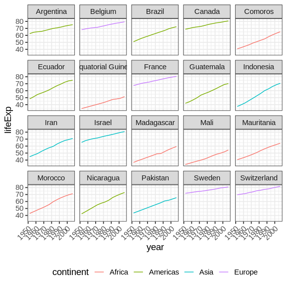

```r
models %>%
  top_n(20, rsq) %>%
  unnest(data) %>%
  ggplot(aes(x = year, y = lifeExp)) +
  geom_line(aes(colour = continent)) +
  facet_wrap(~ country) +
  theme(axis.text.x = element_text(angle = 45,
                                   hjust = 1),
        legend.position = "bottom")
```

## interpreting the linear model

### regression

- what represents the **intercept**?
  - using `year1950`?
  - using `year`?
  - justify Hadley choice
- what represents the **slope**?

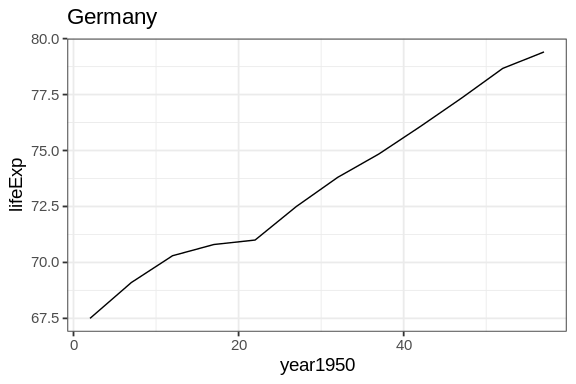

### Germany, lifeExp ~ year1950

```r
filter(models, country == "Germany") %>%
  unnest(tidy) %>%
  select(rsq:estimate)
```

```
# A tibble: 2 x 6
    rsq augment            p.value statistic std.error estimate
  <dbl> <list>               <dbl>     <dbl>     <dbl>    <dbl>
1 0.990 <tibble [12 × 9]> 7.65e-21     282.    0.238     67.1
2 0.990 <tibble [12 × 9]> 3.15e-11      30.7   0.00696    0.214
```

### Germany, lifeExp ~ year

```
# A tibble: 2 x 3
    rsq term        estimate
  <dbl> <chr>          <dbl>
1 0.990 (Intercept) -350.
2 0.990 year           0.214
```

## Summarise on one plot

### by Hadley Wickham

`04:00`

- unnest coefficients (`tidy` column)
  - mind to keep the `continent`, `country` and `rsq` columns
- put **intercept** and **slope** in their own columns
  - in **wide** format, only one value can be used.
  - discard unused columns.
- plot slope ~ intercept (watch out the `(Intercept)` name which needs to be called between backsticks ‘`’)
- colour per continent
- size per \(r^2\) (use for `scale_size_area()` for lisibility)
- add tendency with `geom_smooth(method = "loess")`

## All in all

### by Hadley Wickham

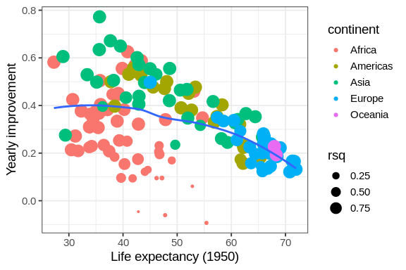

```r
models %>%
  unnest(tidy) %>%
  select(continent, country, rsq, term, estimate) %>%
  spread(term, estimate) %>%
  ggplot(aes(x = `(Intercept)`, y = year1950)) +
  geom_point(aes(colour = continent, size = rsq)) +
  geom_smooth(se = FALSE, method = "loess") +
  scale_size_area() + labs(x = "Life expectancy (1950)", y = "Yearly improvement")
```

## animation made easy

### takes ~ 5 minutes due to easing

### gganimate by Thomas Pedersen

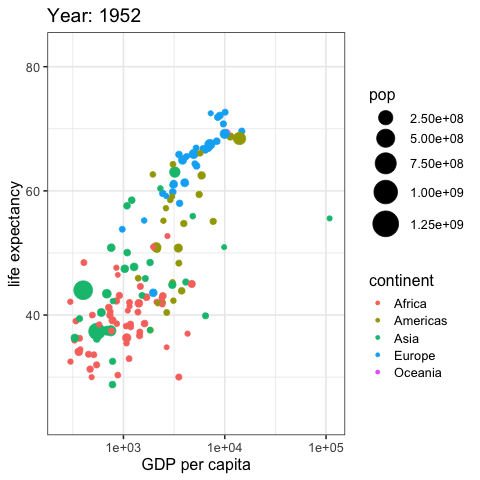

```r
library(gganimate)
gapminder %>%
  ggplot(aes(x = gdpPercap,
             y = lifeExp,
             size = pop,
             color = continent)) +
  transition_time(year) +
  ease_aes("linear") +
  scale_size(range = c(2, 12)) +
  geom_point() +
  theme_bw(16) +
  labs(title = "Year: {frame_time}",
       x = "GDP per capita",
       y = "life expectancy") +
  scale_x_log10() -> p
animate(p)
anim_save("gapminder2.gif")
```

## Before we stop

### You learned to:

- keep related things together:
  - input data
  - meaningful grouping ids
  - perform modelling
  - extract relevant model components
  - explore visually your findings

### Acknowledgments

[figure not shown]

- Hadley Wickham
- Jennifer Bryan
- David Robinson
- Thomas Pedersen
- Eric Koncina (iosp *R* package for slides)

### R workshop @Beval

[figure not shown]

- [*Data processing with R tidyverse*](https://rworkshop.uni.lu/) **4** days in **May 2020**:
- **no** fees, registration via Exilir-LU
- **2 ECTS** for the PhD students who attend the workshop and  
  complete a short project.